# Week 13 Version Control

## Week 13: Version Control

## 1. Version Control

- A system that records changes to a set of files over time
- Easier to collaborate with other people
- Git

## 2. Types of Version Control Systems

- Centralized version control systems
  - A single central server stores all files, and users check out files from this server.

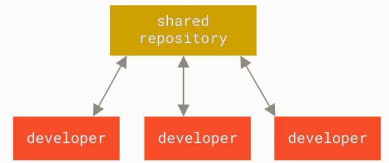

- Distributed version control systems
  - Every user has a complete copy of the repository, including the history of changes.
  - Git

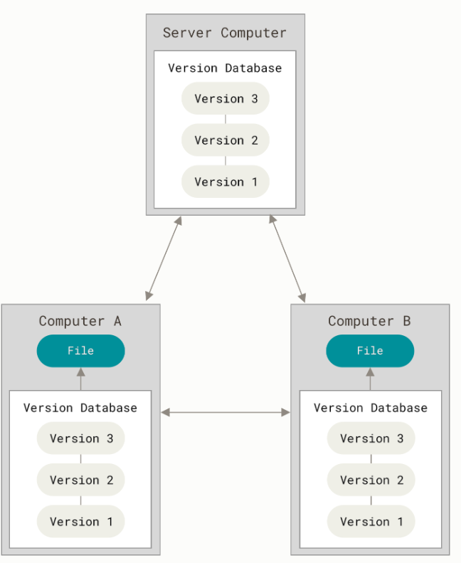

[image source](https://git-scm.com/book/ms/v2/Getting-Started-About-Version-Control)

## 3. Git

Git is a free and open-source distributed version control system designed to handle everything from small to very large projects with speed and efficiency. It allows multiple people to collaborate on a project, keeps track of changes made to files, and provides a way to revert to previous versions when necessary.

## 4. Github

GitHub is a platform for hosting and collaborating on Git repositories. It builds on Git by providing a web-based interface, collaboration tools, and features for version control. GitHub is widely used by developers, researchers, and organizations to manage projects, share code, and collaborate efficiently.

## 5. Sign up the GitHub Account

- Create a [GitHub Account](https://github.com/)
- Include a personal email as back-up email

## 6. Repository in Github

A repository (or 'repo' for short) on GitHub is essentially a storage space where your project's files, including code, documentation, and other resources, are stored.

More detail about [Repository find in GitHub Docs](https://docs.github.com/en/repositories/creating-and-managing-repositories/about-repositories)

## 7. Customize profile

### 7.1 Create new repo

1. Click + on the top right corner
2. Make sure your repo name is the same as your user name
3. Set is as Public and Select 'Add a README file'
4. GitHub will display your profile README on your profile page if all of the following are true.
- You've created a repository with a name that matches your GitHub username.
- The repository is public.
- The repository contains a file named README.md in its root.
- The README.md file contains any content.

[More details](https://docs.github.com/en/account-and-profile/setting-up-and-managing-your-github-profile/customizing-your-profile/managing-your-profile-readme)

### 7.2 Small Tricks to polish profile

#### 7.2.1 Emoji

Copy [emojis](https://emojicopy.com/) and paste them in file

#### 7.2.2 Static Bage

For example is defined as https://img.shields.io/badge/My-LinkedIn-blue

Format that create a LinkedIn badge that connect to your associated account

- [![Alt text](link of badge)](link to content)

### 7.2.3 Dynamic badges

[Dynamic badges](https://shields.io/badges/git-hub-repo-size) can show metrics for your repo or project.

## 8. Installing Git

- https://git-scm.com/downloads

### To test that it is installed correctly

- Open a command prompt (Windows) or Terminal (Mac)

```
git -version
```

### 8.1 set up account name and email address

Set up your account name and email address in Git

- [Setting your username in Git](https://docs.github.com/en/get-started/getting-started-with-git/setting-your-username-in-git)
- [Setting your commit email address](https://docs.github.com/en/account-and-profile/setting-up-and-managing-your-personal-account-on-github/managing-email-preferences/setting-your-commit-email-address)

Check your username and email

```
git config --list --global
```

## 10. Repo in Github

### 10.1 Initialize Repo from Existing code

```
git init
```

```
git add .
```

```
git commit -m "initial commit"
```

### 10.2 Create a new Repo in Github

- Create a repo "SSJ302_lab10"
- Create a README.md file

### 10.3 Clone an existing Repo from remote to local

- Clone this remote repository to local computer

```
git clone <repository_url>
```

Now navigate into your new git repository.

- .git: Git stores information about the project in this special hidden .git sub-directory. If you delete it, you will lose the project's history.

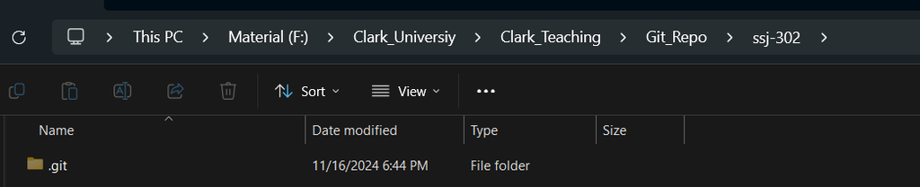

### 10.4 Add content to your repo

Using the html file from Lab 10 as an example to host a web page on Github

### 10.5 Push change from local to Remote

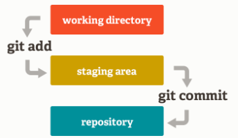

- Make some change to local repository, then update the remote pository based on Step 1 - 3.
1. To add files to the staging area, run the following command:

```
git add .
```

2. To commit the changes, run the following command. Repalce message with your comment to this commit. -m flag (for "message")

```
git commit -m 'message'
```

3. Push the change from local repository to remote repository

```
git push
```

## 11 Syncing

Sometimes, we need to sync our local repository with the main branch (the default branch) on GitHub. For example, imagine you have two computers: one at home and one at work. You made changes on your work computer and pushed them to the main branch on GitHub. However, when you return home, you realize your local copy is outdated.

### 11.1 Pull change from Remote to local

It’s an easy way to synchronize your local repository with upstream changes.

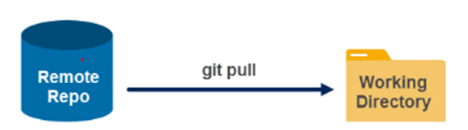

```
git pull
```

## 12. Collaboration

There two main ways to collaborate on github:

1. Adding individual collaborators to a project
2. The fork & pull model

The first method give your collaborator full permission to make changes.

The second method allow you accept individual contributions without full access.

## 13. Fork & Pull

### 13.1 Fork a repo

1. On Github, navigate to https://github.com/gisynw/SSJ302_final_project
2. In the top-right corner of the page, click Fork

### 13.2 Commit a change

1. Clone the repo to your local computer
2. Create a word document (Firstname_Lastname.docx) in the repo
3. Add 1-2 sentence description of the project
4. Add, commit, push the change

### 13.3 Submit a pull request

Navigate to your GitHub repo to check out your change.

When you make change to your SSJ302_final_project repo. Your repo is different from mine, and from everybody else. Next is to share your changes wiht others

1. Click pull request
2. New pull request

## 14. Git Resource

https://git-scm.com/book/en/v2